# ggplot2を使ってみよう

SappoRo.R #5

kazutan

# プロット作成

- Rには標準で多様なプロットを作成可能
- 様々なところで説明されています
  - Hiroshima.R #3 の[初心者セッションスライド](http://wwww.slideshare.net/sakaue/hiroshimar3intror)
  - 82枚目あたりから解説されています
- 今日は可視化のパッケージ`{ggplot2}`を紹介します

# さっそくプロット

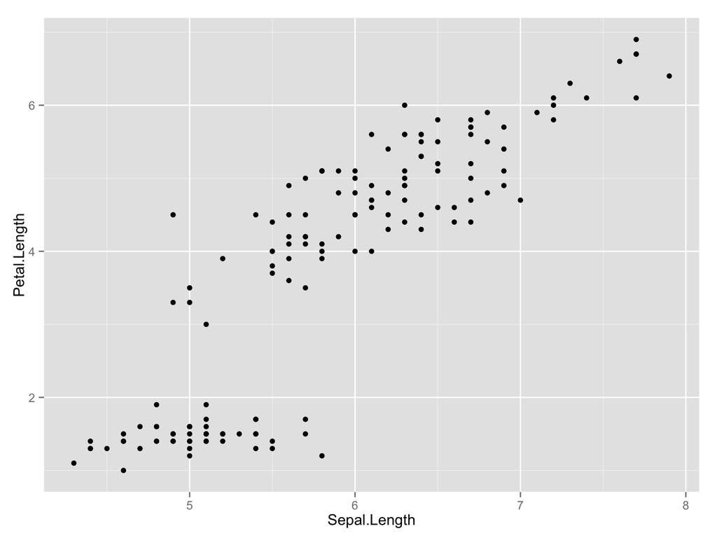

```r
library(ggplot2)
ggplot(iris, aes(y=Petal.Length, x=Sepal.Length)) +
  geom_point()
```

- さっくりできた!

# 解説

```r
ggplot(iris, aes(y=Petal.Length, x=Sepal.Length)) +
  geom_point()
```

### ggplot2はレイヤー構造

- 一行目: 基本レイヤー
  - 可視化するデータを指定します
  - aes()の中で、x軸の変数とy軸の変数を指定
- 二行目: プロット方法
  - `geom_point()`で「散布図書いて」となる
  - 他のは後述

# 水準ごとで分けたい

```r
ggplot(iris, aes(y=Petal.Length, x=Sepal.Length, col=Species)) +
  geom_point()
```

- Speciesの内容ごとで色分けされた!
  - aes()内に`col=Species`を追加
  - これは「色をSpeciesで塗り分けて」という意味になる

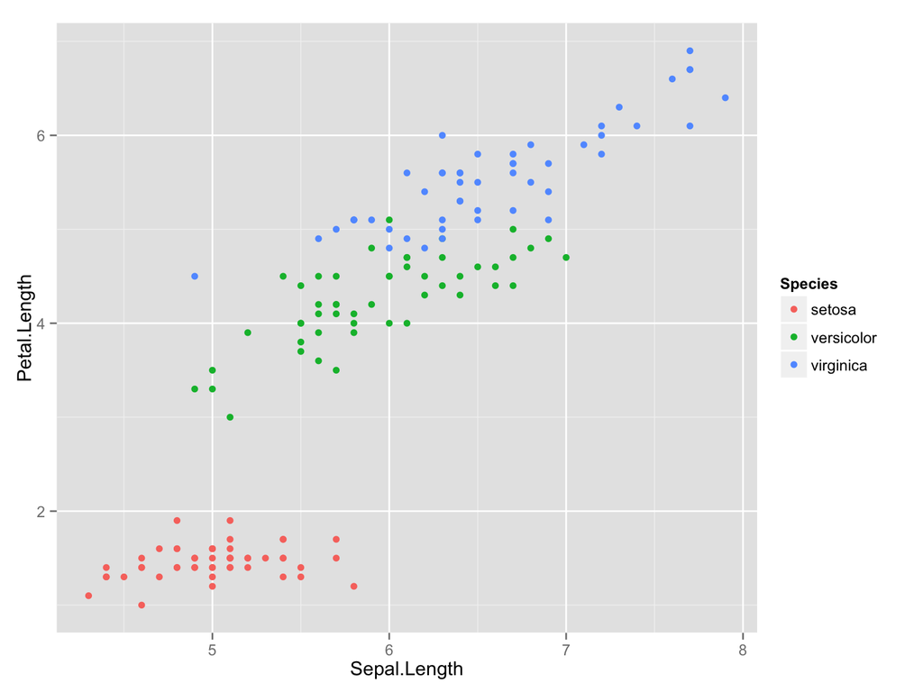

# ラベルを設定したい

```r
ggplot(iris, aes(y=Petal.Length, x=Sepal.Length, col=Species)) +
  geom_point() +
  labs(title="iris-tan", x="yokoyoko", y="tatetate")
```

- 表のタイトル、x軸ラベル、y軸ラベルが設定されます
- このほか様々な設定が可能です

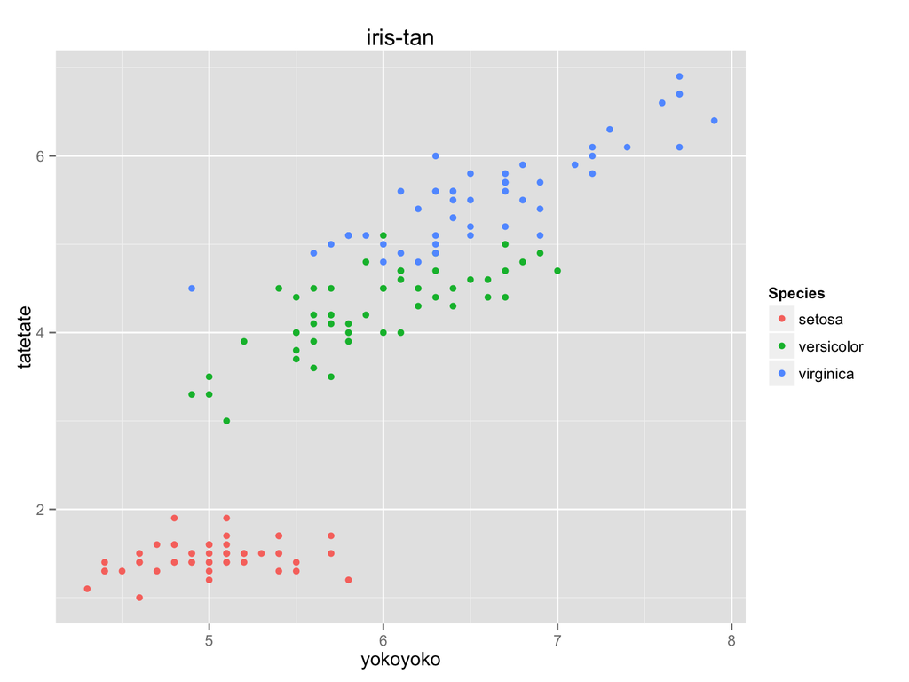

# 背景テーマ変更 + 文字を大きく

```r
ggplot(iris,aes(y=Petal.Length,x=Sepal.Length, col=Species)) +
  geom_point() +
  theme_bw(base_size = 20)
```

- theme_*でテーマ設定
  - theme_bw()は黒白テーマ
  - base_sizeで基本の文字サイズ変更(デフォルトは12)
  - base_familyでフォントファミリー変更可能(省略)

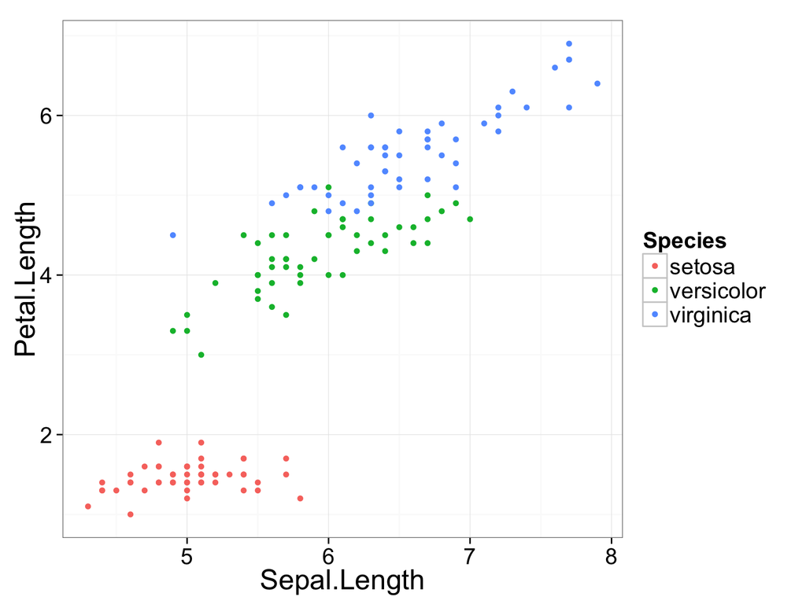

# 箱ひげ図を出したい

```r
ggplot(iris, aes(y=Petal.Length,x=Species)) +
  geom_boxplot()
```

- geom_boxplot()で箱ひげ図
  - x軸にはfactor型というデータ形式で

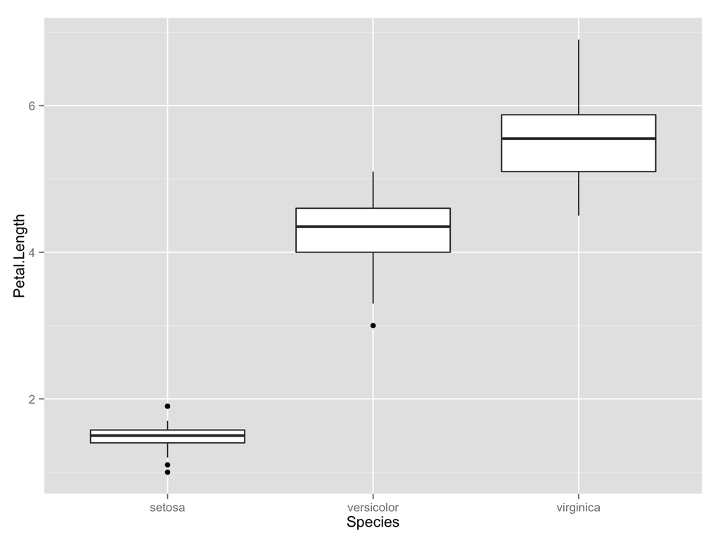

# 箱ひげ図にさらに追加

```r
ggplot(iris, aes(y=Petal.Length,x=Species)) +
  geom_boxplot() + geom_jitter()
```

- geom_boxplot()で箱ひげ図
  - x軸にはfactor型というデータ形式で

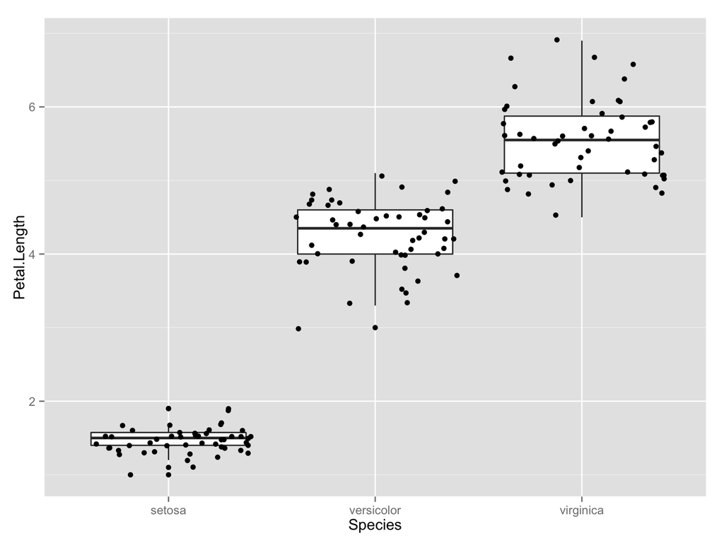

# 棒グラフを出したい(度数分布表)

```r
ggplot(iris, aes(Petal.Length)) +
  geom_bar()
```

```
## stat_bin: binwidth defaulted to range/30. Use 'binwidth = x' to adjust this.
```

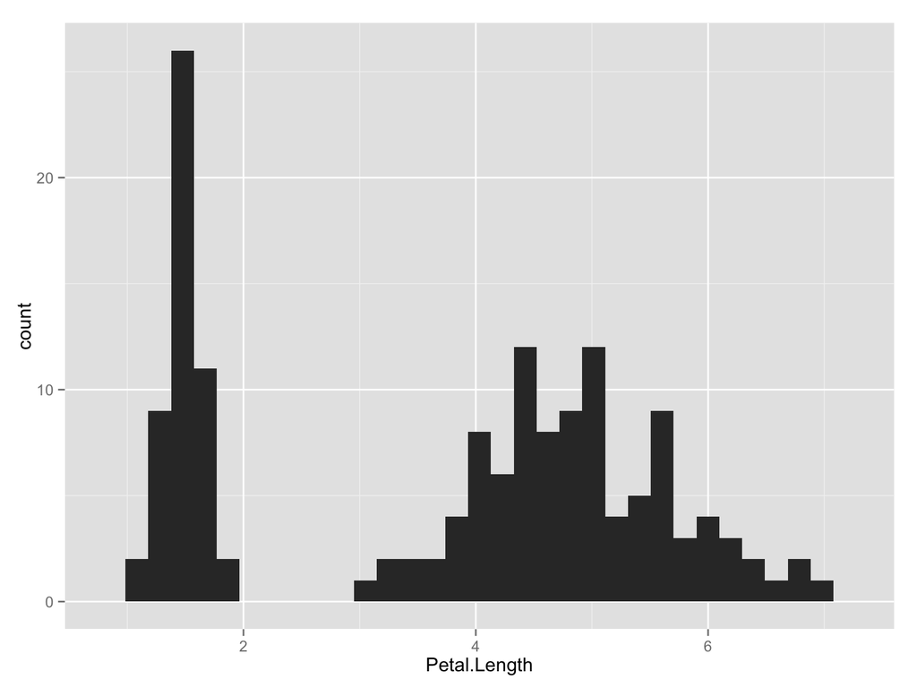

# 棒グラフを出したい(平均値の棒グラフ)

```r
ggplot(iris, aes(y=Petal.Length, x=Species)) +
  stat_summary(fun.y=mean,geom="bar")
```

- stat_summary()で、データを要約して可視化
  - おおざっぱに例えると「f(y)=mean(y)として要約して棒にして」

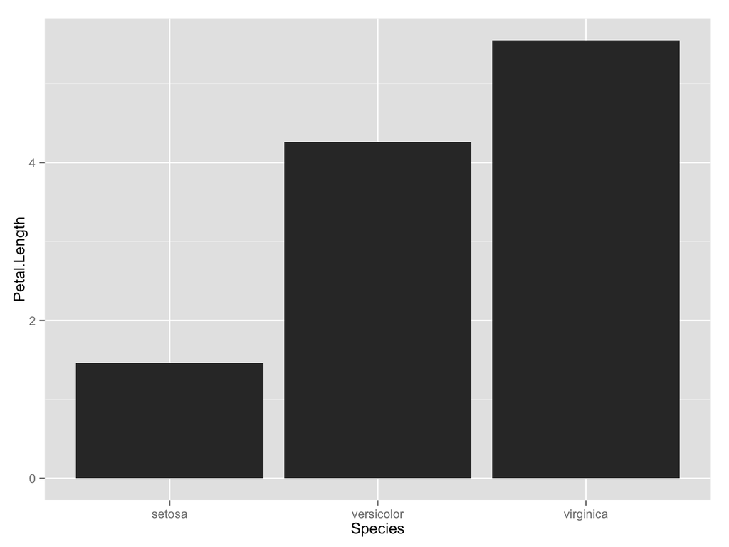

# もっと!もっと!

- ぜひ自分で調べてみましょう
- ggplot2について厳選したリンク集を作成しました  
  [ggplot2に関する資料まとめ](http://qiita.com/kazutan/items/c42031ec54be283efd4f)